# Praca domowa 2

Magdalena Forowicz

## Dane

Dane wykorzystane w Pracy domowej 2 dotyczą wyników egzaminów z 3 umiejętności: czytania, pisania i operacji matematycznych. Dodatkowo dostępne są podstawowe informacje o studentach i ich rodzicach. Opis wszystkich kolumn znajduje się również w pliku `README.md`.

| Zmienna | Opis |
| --- | --- |
| **gender** | płeć |
| **race.ethnicity** | pochodzenie etniczne |
| **parental.level.of.education** | wykształcenie rodziców |
| **lunch** | jaki obiad jedli uczniowie w dniu egzaminu |
| **test.preparation.course** | czy uczeń odbył kurs przygotowujący |
| **math.score** | wynik egzaminu z matematyki |
| **reading.score** | wynik egzaminu z czytania |
| **writing.score** | wynik egzaminu z pisania |

## Zadanie 1

Jak wyglądają rozkłady wyników uczniów z trzech przedmiotów (matematyka, czytanie, pisanie)?

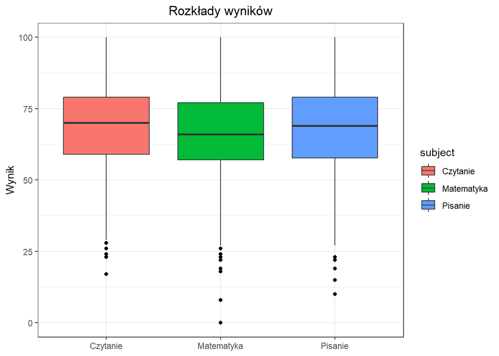

```r
df_long <- df %>% rename(Matematyka = math.score,
                              Czytanie = reading.score,
                              Pisanie = writing.score) %>%
  pivot_longer(cols = c(Matematyka, Czytanie, Pisanie),
    names_to = "subject",
    values_to = "score")

ggplot(df_long, aes(x = subject, y = score, fill = subject)) +
  geom_boxplot(outlier.color = "black") +
  labs(title = "Rozkłady wyników", x = NULL, y = "Wynik") +
  theme_bw() +
  theme(plot.title = element_text(hjust = 0.5))
```

**Komentarz:** Jak widać wartość średnia dla Matematyki jest niższa od dwóch pozostalych które są niemal identyczne i sięgają do wyniku około 70. Wysokości pudelek również są zbliżone i świadczą o tym, że dla wszystkich przedmiotów środkowe 50% danych zawiera się w podobnym zakresie. Dla matematyki obserwujemy też więcej outlierow niż dla Pisania czy Czytania.

## Zadanie 2

Czy istnieje zauważalna różnica w wynikach między uczniami i uczennicami?

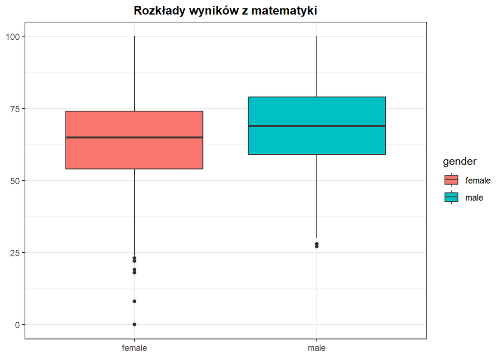

```r
df_long %>% filter(subject == "Matematyka") %>%
  ggplot(aes(x = gender, y = score, fill = gender)) +
  geom_boxplot() +
  labs(title = "Rozkłady wyników z matematyki", x = NULL, y = NULL) +
  theme_bw() +
  theme(plot.title = element_text(hjust = 0.5, face = "bold", size = 12))
```

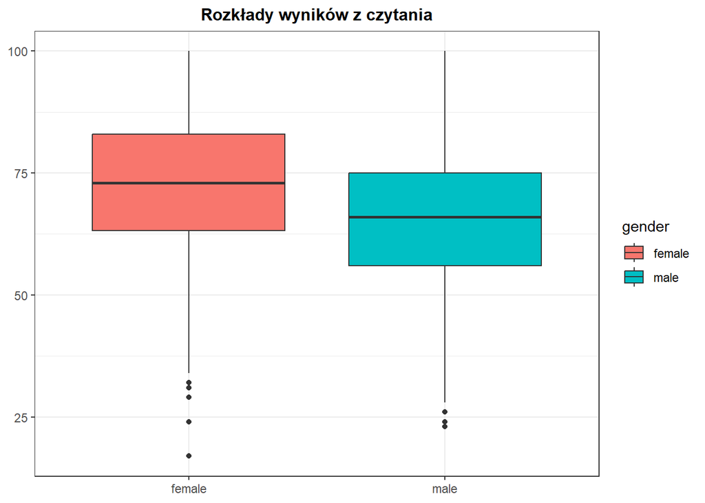

```r
df_long %>% filter(subject == "Czytanie") %>%
  ggplot(aes(x = gender, y = score, fill = gender)) +
  geom_boxplot() +
  labs(title = "Rozkłady wyników z czytania", x = NULL, y = NULL) +
  theme_bw() +
  theme(plot.title = element_text(hjust = 0.5, face = "bold", size = 12))
```

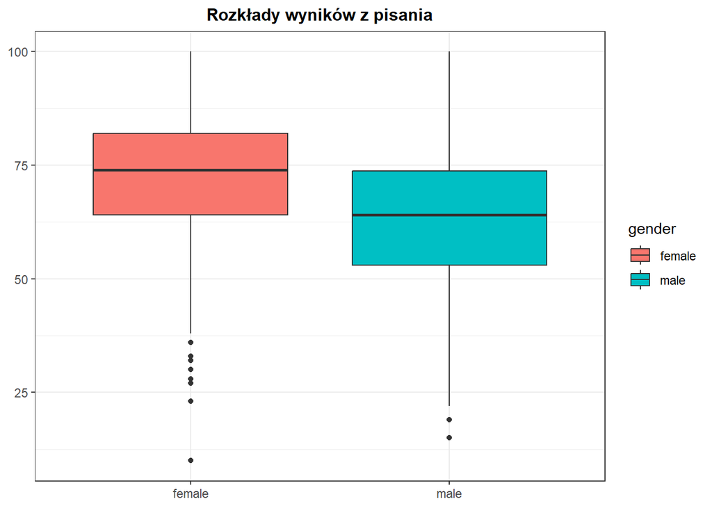

```r
df_long %>% filter(subject == "Pisanie") %>%
  ggplot(aes(x = gender, y = score, fill = gender)) +
  geom_boxplot() +
  labs(title = "Rozkłady wyników z pisania", x = NULL, y = NULL) +
  theme_bw() +
  theme(plot.title = element_text(hjust = 0.5, face = "bold", size = 12))
```

**Komentarz:** Jak widać w mateamtyce, przeciętnie uczniowie są bardziej utalentowani, aczkolwiek zarówno w czytaniu jaki i pisaniu są to uczennice.

## Zadanie 3

Czy uczniowie, którzy ukończyli kurs przygotowawczy, osiągają lepsze wyniki niż pozostali?

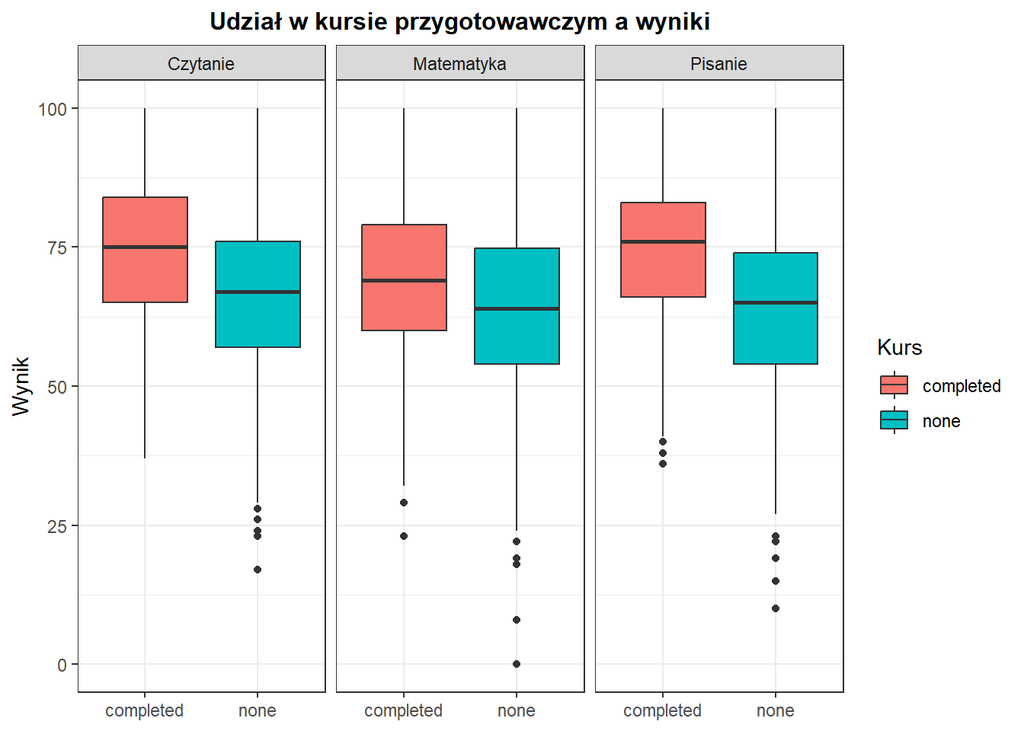

```r
ggplot(df_long, aes(x = test.preparation.course, y = score, fill = test.preparation.course)) +
  geom_boxplot() +
  facet_wrap(~ subject) +
  labs(title = "Udział w kursie przygotowawczym a wyniki",
       x = NULL,
       y = "Wynik",
       fill = "Kurs") +
  theme_bw() +
  theme(plot.title = element_text(hjust = 0.5, face = "bold", size = 12))
```

**Komentarz:** Tak, ewidentnie uczniowie którzy podjęli się udzialu w kursie przygotowawczym osiągnęli średnio lepsze wyniki od pozostałych. Również pojawia się znacznie mniej wartości odstających dla tych którzy ukończyli kurs.

## Zadanie 4

Jaki jest związek między poziomem wykształcenia rodziców a średnimi wynikami uczniów?

[figure not shown]

```r
dane <- df %>%
  mutate(parental.level.of.education = factor(
    parental.level.of.education,
    levels = c("some high school",
               "high school",
               "some college",
               "associate's degree",
               "bachelor's degree",
               "master's degree"))) %>%
  group_by(parental.level.of.education, gender) %>%
  summarise(Matematyka = mean(math.score, na.rm = TRUE),
            Czytanie = mean(reading.score, na.rm = TRUE),
            Pisanie = mean(writing.score, na.rm = TRUE)) %>%
  pivot_longer(cols = c(Matematyka, Czytanie, Pisanie), names_to = "Przedmiot",
               values_to = "Średni_wynik")

math_data <- dane %>% filter(Przedmiot == "Matematyka")
reading_data <- dane %>% filter(Przedmiot == "Czytanie")
writing_data <- dane %>% filter(Przedmiot == "Pisanie")


ggplot(math_data, aes(
  x = parental.level.of.education,
  y = Średni_wynik,
  fill = parental.level.of.education)) +
  geom_col(show.legend = FALSE) +
  labs(
    x = "Poziom wykształcenia rodziców",
    y = "Średni wynik uczniów z Matematyki") +
  theme(axis.text.x = element_text(angle = 45, hjust = 1))
```

[figure not shown]

```r
ggplot(reading_data, aes(
  x = parental.level.of.education,
  y = Średni_wynik,
  fill = parental.level.of.education)) +
  geom_col(show.legend = FALSE, width = 0.7) +
  labs(
    x = "Poziom wykształcenia rodziców",
    y = "Średni wynik uczniów z Pisania") +
  theme(axis.text.x = element_text(angle = 45, hjust = 1))
```

[figure not shown]

```r
ggplot(writing_data, aes(
  x = parental.level.of.education,
  y = Średni_wynik,
  fill = parental.level.of.education)) +
  geom_col(show.legend = FALSE, width = 0.7) +
  labs(
    x = "Poziom wykształcenia rodziców",
    y = "Średni wynik uczniów z Czytania") +
  theme(axis.text.x = element_text(angle = 45, hjust = 1))
```

## Zadanie 5

Czy płeć i wykształcenie rodzica wpływa na wynik z matematyki?

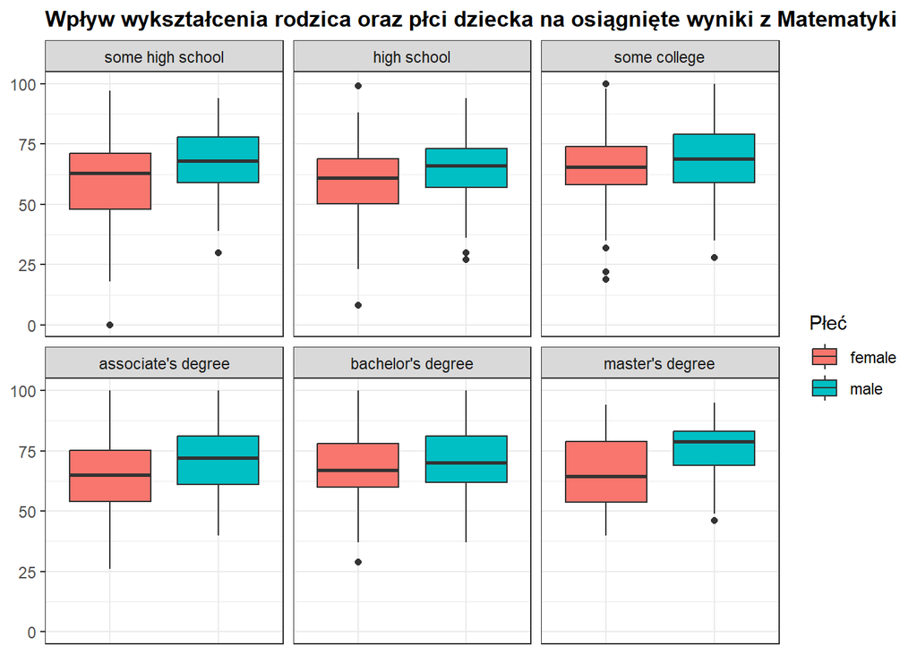

```r
df_long %>% mutate(parental.level.of.education = factor(
    parental.level.of.education,
    levels = c("some high school",
               "high school",
               "some college",
               "associate's degree",
               "bachelor's degree",
               "master's degree"))) %>%
  filter(subject == "Matematyka") %>%
  ggplot(aes(x = gender, y = score, fill = gender)) +
  geom_boxplot() +
  facet_wrap(~parental.level.of.education) +
  labs(
    title = "Wpływ wykształcenia rodzica oraz płci dziecka na osiągnięte wyniki z Matematyki",
    x = NULL,
    y = NULL,
    fill = "Płeć") +
  theme_bw() +
  theme(plot.title = element_text(face = "bold", size = 12),
        axis.text.x = element_blank(),
        axis.ticks.x = element_blank())
```

**Komentarz:** Tak. Wyższe wyniki z matematyki osiągają uczniowie niż uczennice. Również rodzice uczniów z najwyższymi wynikami mają wyksztacenie magisterskie, zaś rodzice uczennic z najwyższymi wynikami - licencjackie

## Zadanie 6

Czy istnieje zależność między wynikami z matematyki a wynikami z czytania lub pisania?

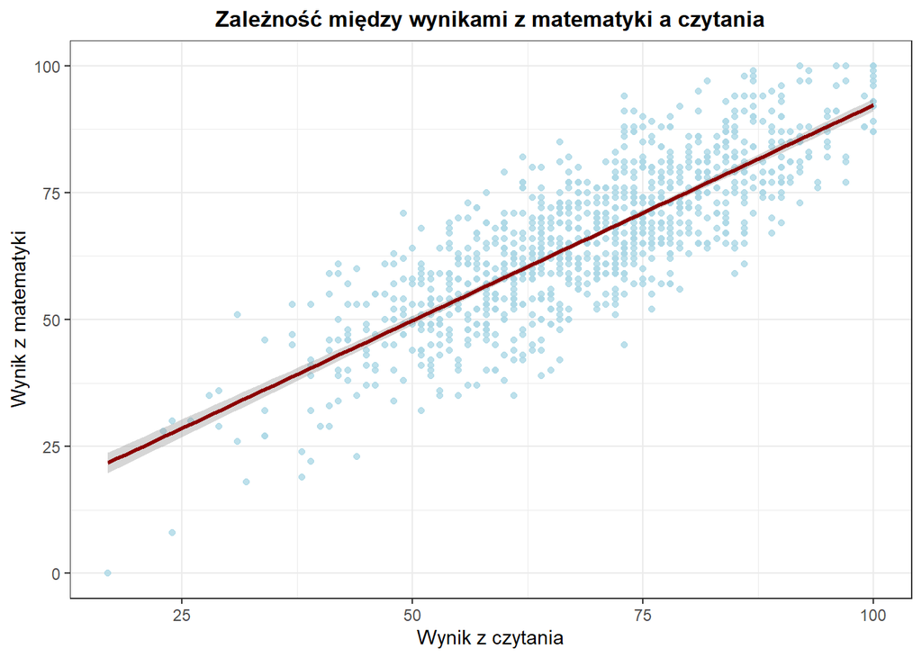

```r
ggplot(df, aes(x = reading.score, y = math.score)) +
  geom_point(alpha = 0.8, color = "lightblue") +
  geom_smooth(method = "lm", color = "darkred") +
  labs(
    title = "Zależność między wynikami z matematyki a czytania",
    x = "Wynik z czytania",
    y = "Wynik z matematyki"
  ) +
  theme_bw() +
  theme(plot.title = element_text(hjust = 0.5, face = "bold", size = 12))
```

[figure not shown]

```r
ggplot(df, aes(x = writing.score, y = math.score)) +
  geom_point(alpha = 0.8, color = "lightblue") +
  geom_smooth(method = "lm", color = "darkred") +
  labs(
    title = "Zależność między wynikami z matematyki a pisania",
    x = "Wynik z czytania",
    y = "Wynik z matematyki"
  ) +
  theme_bw() +
  theme(plot.title = element_text(hjust = 0.5, face = "bold", size = 12))
```

**Komentarz:** Tak, zależność ta istnieje co dobrze widać na powyższych wykresach. Im lepsze wyniki z matematyki tym lepsze wyniki z czytania i pisania